# Unconditional simulations of SLGPs, and computing continuity rates.

Athénaïs Gautier

Last revised - January 2025

# Result considered for this document

In our paper , for $D \subset \mathbb{R}^{d_D}$ a compact and convex index space with $d_D\geq 1$, we prove the following result:

$\textbf{Condition 1}$  
There exist $C, \alpha_1, \alpha_2 >0$ such that for all $\mathbf{x}, \mathbf{x}' \in D, t, t' \in \mathcal{T}$: $\begin{equation*} k([\mathbf{x}, t], [\mathbf{x}, t]) + k([\mathbf{x}', t'],[\mathbf{x}', t']) - 2 k([\mathbf{x}, t], [\mathbf{x}', t']) \leq C \cdot \max(\Vert \mathbf{x}- \mathbf{x}' \Vert_\infty ^{\alpha_1}, \Vert t - t' \Vert_\infty ^{\alpha_2}) \end{equation*}$

Where for two pdfs $f_1$, $f_2$ on $\mathcal{T}$:

- $d_{H}$ denotes the Hellinger distance: $d_H(f_1, f_2) := \sqrt{\frac{1}{2}\int_\mathcal{T}\left( \sqrt{f_1(u)} - \sqrt{f_2(u)} \right)^2 \,du}$
- $KL$ denotes the Kullback-Liebler divergence: $KL(f_1, f_2) := \int_\mathcal{T}f_1(u) \log\left( f_1(u) / f_2(u)\right) \,du$
- $V$ denotes a squared log-ratio dissimilarity: $V(f_1, f_2) := \int_\mathcal{T}\left( \log \frac{ f_1(u)}{f_2(u)}\right)^2 \,du$
- $d_{TV}$ denotes the Total Variation distance: $d_{TV}(f_1, f_2) := \int_\mathcal{T}\left\vert f_1(u) - f_2(u) \right\vert \,du$

# Deriving Hölder exponents in our theoretical upper bounds:

In order to numerically validate the bounds in this Theorem, we first need to find the values of the Hölder exponents in the Condition for some kernels of interest.

Three of the most commonly encountered kernels in spatial statistics are, for $\boldsymbol y=[\mathbf{x}, t], \boldsymbol y'=[\mathbf{x}', t'] \in D\times \mathcal{T}$:

- The exponential kernel:  
  $k_{exp}(\boldsymbol y, \boldsymbol y') = \exp\{-\Vert \mathbf{x}- \mathbf{x}\Vert_2 \} \cdot \exp\{-\vert t - t'\vert \}$
- The Matérn-type kernel with half-integer smoothness parameter $\nu=p+\frac{1}{2}$:  
  $k_{mat, \nu}(\boldsymbol y, \boldsymbol y') = P_\nu(\sqrt{\Vert \mathbf{x}- \mathbf{x}\Vert_2^2 + (t-t')^2})\exp\{-\Vert \mathbf{x}- \mathbf{x}\Vert_2 \} \cdot \exp\{-\vert t - t'\vert \}$  
  where $P_\nu$ is a polynomial such that $P_\nu(0)=1$.
- The Gaussian kernel:  
  $k_{gau}(\boldsymbol y, \boldsymbol y') = \exp\{-\Vert \mathbf{x}- \mathbf{x}\Vert_2^2 /2 \} \cdot \exp\{-( t - t')^2 /2 \}$

First, we note that since $P_\nu(0)=1$, the Matérn-type kernels are all equivalent to the exponential kernel at the neighborhood of $0$, and will therefore have the same exponent. Therefore, we will focus on the exponential kernel here.

Then, we also observe that the exponential and Gaussian kernel are tensored kernels, where $\mathbf{x}$ and $t$ play similar roles. As such, they will have the same Hölder exponent in both variables. Finally, note that for any $\alpha >0$:

- For the exponential kernel:
  $$\begin{align}
  \frac{d_{k_{exp}}^2(\boldsymbol y, \boldsymbol y')}{\Vert
  \boldsymbol y - \boldsymbol y' \Vert^\alpha_\infty} &=
  \frac{k_{exp}(\boldsymbol y, \boldsymbol y) + k_{exp}(\boldsymbol
  y', \boldsymbol y') - 2 k_{exp}(\boldsymbol y, \boldsymbol
  y')}{\Vert \boldsymbol y - \boldsymbol y' \Vert^\alpha_\infty}\\
  &= \frac{2 - 2 k_{exp}(\boldsymbol y, \boldsymbol y')}{\Vert
  \boldsymbol y - \boldsymbol y' \Vert^\alpha_\infty}\\
  &= \frac{2 - 2 \exp \{ - \Vert \boldsymbol y - \boldsymbol
  y'\Vert_2 \} }{\Vert \boldsymbol y - \boldsymbol y'
  \Vert^\alpha}\\
  &= \frac{ 2 \Vert \boldsymbol y - \boldsymbol y'\Vert_2 -
  \mathcal{O}( \Vert \boldsymbol y - \boldsymbol y'\Vert^2_2) }{\Vert
  \boldsymbol y - \boldsymbol y' \Vert^\alpha_\infty}
  \end{align}$$
  It follows immediately from this Taylor expansion that the Hölder exponent of the exponential kernel is $\alpha=1$.
- For the Gaussian kernel:
  $$\begin{align}
  \frac{d_{k_{gau}}^2(\boldsymbol y, \boldsymbol y')}{\Vert
  \boldsymbol y - \boldsymbol y' \Vert^\alpha_\infty} &=
  \frac{k_{gau}(\boldsymbol y, \boldsymbol y) + k_{gau}(\boldsymbol
  y', \boldsymbol y') - 2 k_{gau}(\boldsymbol y, \boldsymbol
  y')}{\Vert \boldsymbol y - \boldsymbol y' \Vert^\alpha_\infty}\\
  &= \frac{2 - 2 k_{gau}(\boldsymbol y, \boldsymbol y')}{\Vert
  \boldsymbol y - \boldsymbol y' \Vert^\alpha_\infty}\\
  &= \frac{2 - 2 \exp \{ - \Vert \boldsymbol y - \boldsymbol
  y'\Vert_2^2 /2 \} }{\Vert \boldsymbol y - \boldsymbol y'
  \Vert^\alpha}\\
  &= \frac{ \Vert \boldsymbol y - \boldsymbol y'\Vert_2^2 -
  \mathcal{O}( \Vert \boldsymbol y - \boldsymbol y'\Vert^4_2) }{\Vert
  \boldsymbol y - \boldsymbol y' \Vert^\alpha_\infty}
  \end{align}$$
  It follows immediately from this Taylor expansion that the Hölder exponent of the Gaussian kernel is $\alpha=2$.

# Unconditional simulations of 2D GPs, and transformation in SLGPs.

We use the package RandomFields to draw our unconditional simulations. It is not currently available directly from CRAN, but can be installed from the archive.

```r
require(devtools)
# paste0 to prevent the link to run out of page when Knitting as a pdf
install.packages(paste0("https://cran.r-project.org/src/contrib/Archive/",
                        "RandomFieldsUtils/RandomFieldsUtils_1.2.5.tar.gz"),
                 repos = NULL, type = "source")
install.packages(paste0("https://cran.r-project.org/src/contrib/Archive/",
                        "RandomFields/RandomFields_3.3.14.tar.gz"),
                 repos = NULL, type = "source")
```

Now, on a regular grid of size $51\times 51$, we can perform unconditional simulations of GPs with either Exponential or Gaussian kernel :

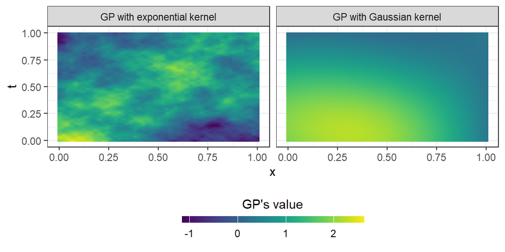

Unconditional simulations of GPs with our two kernels of interest

```r
u <- seq(0, 1,, 51)
dfGrid <- data.frame(expand.grid(u, u))
colnames(dfGrid) <- c("x", "t")
library(RandomFields)
mod1 <- RMexp()
mod2 <- RMgauss()

set.seed(1)
dfGrid$`GP with exponential kernel` <- RFsimulate(model=mod1,
                                                  x=dfGrid[, c(1, 2)],
                                                  grid=FALSE,
                                                  n=1)@data[, 1]
set.seed(1)
dfGrid$`GP with Gaussian kernel` <- RFsimulate(model=mod2,
                                               x=dfGrid[, c(1, 2)],
                                               grid=FALSE,
                                               n=1)@data[, 1]
dfGrid %>%
  pivot_longer(-c("x", "t"))%>%
  ggplot()+
  geom_raster(mapping=aes(x=x, y=t, fill=value), interpolate=TRUE)+
  facet_grid(.~name)+
  scale_fill_viridis(option = "viridis",
                     guide = guide_colorbar(nrow = 1,
                                            title = "GP's value",
                                            barheight = unit(2, units = "mm"),
                                            barwidth = unit(55, units = "mm"),
                                            title.position = 'top',
                                            label.position = "bottom",
                                            title.hjust = 0.5))+
  theme_bw()+ theme(legend.position = "bottom")
```

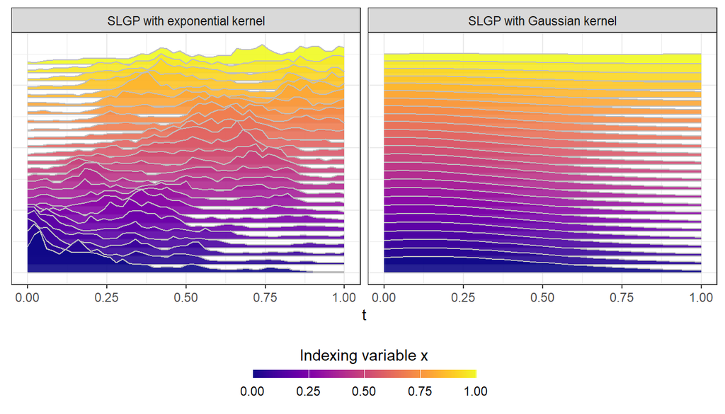

Unconditional simulations of SLGPs with our two kernels of interest

```r
scale_factor <- 0.05

dfGrid %>%
  dplyr::filter(x %in% seq(0, 1,, 26))%>%
  pivot_longer(-c("x", "t"))%>%
  rename(GP=value)%>%
  group_by(x, name)%>%
  mutate(SLGP=exp(GP-max(GP))/mean(exp(GP-max(GP))),
         name=paste0("SL", name))%>%
  ggplot(aes(x=t, ymax=scale_factor*SLGP+x, ymin=x, group=-x, fill=x))+
  geom_ribbon(col="grey", alpha=0.9)+  # Add grey borders around each tile
  scale_fill_viridis(option = "plasma",
                     guide = guide_colorbar(nrow = 1,
                                            title = "Indexing variable x",
                                            barheight = unit(2, units = "mm"),
                                            barwidth = unit(55, units = "mm"),
                                            title.position = 'top',
                                            label.position = "bottom",
                                            title.hjust = 0.5))+
  facet_grid(.~name)+
  theme_bw()+
  theme(legend.position = "bottom",
                    axis.text.y = element_blank(),
                    axis.ticks.y = element_blank(), axis.line.y = element_blank())
```

# Deriving the rates

In turn, we can simulate GPs (and transform them into SLGPs) with a step-size for $x$ that becomes increasingly smaller when getting close to zero.

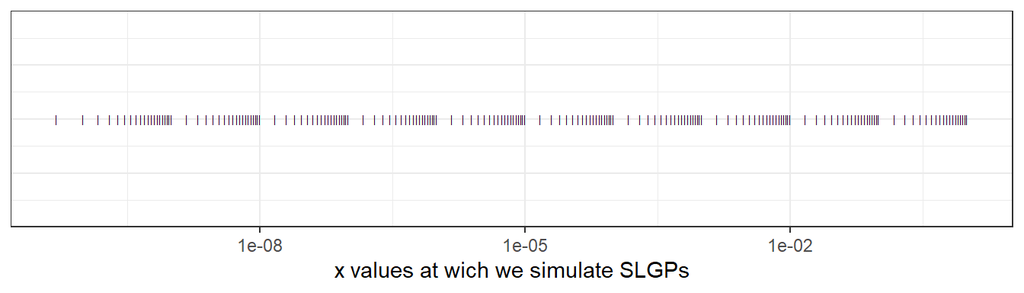

The x values used, with smaller step sizes around zero (log-scale).

```r
# Define parameters for the sequence generation
start_values <- c(0, 1e-9, 1e-8, 1e-7, 1e-6, 1e-5, 1e-4, 1e-3, 1e-2, 1e-1)
end_values <- c(1e-9, 1e-8, 1e-7, 1e-6, 1e-5, 1e-4, 1e-3, 1e-2, 1e-1, 1)
step_factors <- 0.05*end_values
# Initialize the sequence
ux <- numeric()
# Generate the sequence
for (i in 1:length(start_values)) {
  # Generate each segment
  segment <- seq(from = start_values[i], to = end_values[i], by = step_factors[i])
  # Remove the first element if not the first segment
  if (i > 1) segment <- segment[-1]
  # Append the segment to the overall sequence
  ux <- c(ux, segment)
}

ut <- seq(0, 1,, 101)
dfGrid <- data.frame(expand.grid(ux, ut))
colnames(dfGrid) <- c("x", "t")

ggplot()+
  geom_point(mapping=aes(x=ux, y=0), pch="|")  +
  scale_x_log10()+
  theme_bw()+
  labs(y = NULL, x="x values at wich we simulate SLGPs") +
  guides(y = "none")
```

We use 100 repetitions (10 batches of 10 simulations, to accommodate for laptops with small memories).

```r
L <- list()
L[[1]] <- L[[2]] <- list()
deb <- Sys.time()
for(ref in seq(2)){
  if(ref==1){
    mod <- mod1
  }else{
    mod <- mod2
  }
  for(rep in seq(10)){
    print(paste0("Starting repetition ",
                 rep, " of ref ", ref, " after ",
                 round(difftime(Sys.time(), deb, unit="mins"), 1), " minutes."))
    set.seed(rep)
    #visualise
    GP <- RFsimulate(model=mod, x=dfGrid, grid=FALSE, n=10) # 10 batches of 10 for memory issues
    GP <- as.matrix(GP@data)
    colnames(GP) <- paste0("Draw", seq(ncol(GP)))
    dfTemp <- data.frame(dfGrid, GP)
    dfTemp <- dfTemp%>%
      pivot_longer(-c("x", "t"))%>%
      rename(GP=value)%>%
      group_by(x, name)%>%
      mutate(SLGP=exp(GP-max(GP))/mean(exp(GP-max(GP))))%>%
      ungroup()%>%
      dplyr::select(-GP)%>%
      data.frame()
    dfRef <- dfTemp %>%
      filter(x==0) %>%
      dplyr::select(-x)
    colnames(dfRef)[3] <- "SLGP0"
    dfTemp <- merge(dfTemp, dfRef, all.x=TRUE, by=c("t", "name"))
    dfTemp <- dfTemp%>%
      group_by(x, name)%>%
      summarise(dH = sqrt(mean((sqrt(SLGP)-sqrt(SLGP0))^2)),
                dTV = mean(abs(SLGP - SLGP0)),
                V = mean((log(SLGP/SLGP0))^2),
                KL= mean(SLGP*log(SLGP/SLGP0)),
                .groups = "keep")%>%
      mutate(rep=rep,
             ref=c("Exponential kernel", "Gaussian kernel")[ref])%>%
      data.frame()
    L[[ref]][[rep]]<- dfTemp
  }
}
save(L, file="saved_distances_unconditional.RData")
```

We decided to do the computations and save them in $L$ to make them available at any time without having to run all the simulations every time (in the authors current laptop, simulations are performed in approximately 5 minutes).

We then need to merge the data frame containing the distances, and compute the expected values in the left-hand terms of our theorem, as well as the theoretical bound for the right-hand term.

```r
load(file="saved_distances_unconditional.RData")
# Merging the dataframes
df_dist <- data.frame()
for(ref in seq(2)){
  for(rep in seq(10)){
    df_dist <- rbind(df_dist, L[[ref]][[rep]])
  }
}
# Theoretical rates
df_theoretical1 <- unique(df_dist[,c("x", "ref")])
df_theoretical <- data.frame()
for(gamma in c(0.5, 1, 2)){
  for(dist in seq(4)){
    df_theoretical1$gamma<- gamma
    df_theoretical1$name <- c("dH", "dTV", "KL", "V")[dist]
    df_theoretical1$value <- ifelse(df_theoretical1$ref=="Exponential kernel",
                                    df_theoretical1$x^(1*gamma*c(0.5, 0.5, 1, 1)[dist]),
                                    df_theoretical1$x^(2*gamma*c(0.5, 0.5, 1, 1)[dist]))
    df_theoretical <- rbind(df_theoretical,
                            df_theoretical1)
  }
}
rm(df_theoretical1)

#Empirical rates
df_empirical<- data.frame()
for(gamma in c(0.5, 1, 2)){
  df_empirical1 <- df_dist
  df_empirical1$gamma<- gamma
  df_empirical1<-df_empirical1 %>%
    dplyr::select(c("x", "ref", "dH", "dTV", "KL", "V", "gamma"))%>%
    pivot_longer(-c("x", "ref", "gamma"))%>%
    group_by(x, ref, name, gamma) %>%
    mutate(value=round(value, 15))%>% #numerical stability
    summarise(value=mean(value^gamma), .groups="keep")%>%
    ungroup()%>%
    data.frame()
  df_empirical <- rbind(df_empirical,
                        df_empirical1)
}
rm(df_empirical1)
```

Finally, we re-scale (by a constant) every curve to display everything on the same plot with the same plot, and produce the Figure from the paper.

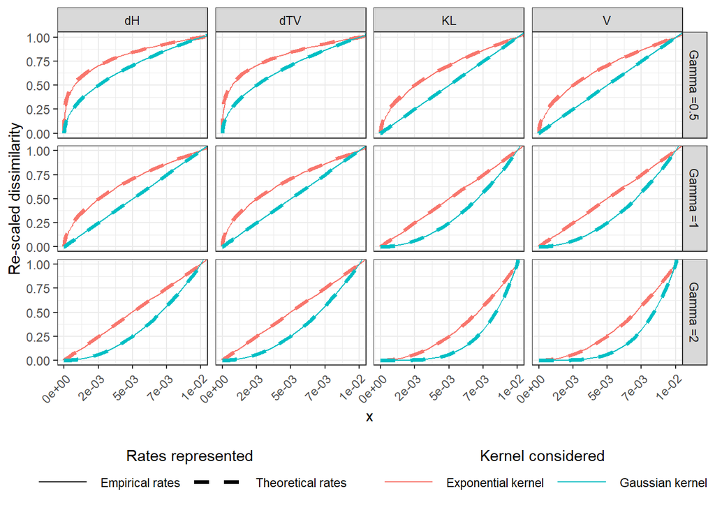

Empirical and theoretical rates, as estimated on unconditional simulations

```r
max_x <- 0.01
df_empirical$type <- "Empirical rates"
df_theoretical$type <- "Theoretical rates"
df_plot <- rbind(df_empirical,
                 df_theoretical)
df_plot%>%
  group_by(ref, type, gamma, name)%>%
  filter(x <= 2*max_x)%>%
  mutate(value=value/max(value*1*(x<=max_x)))%>%
  mutate(gamma=paste0("Gamma =", gamma)) %>%
  ggplot(aes(x=x, y=value, col=ref, lty=type, lwd=type))+
  geom_line()+
  theme_bw()+
  facet_grid(gamma~name)+
  coord_cartesian(ylim=c(0, 1), xlim=c(0, max_x))+
  ylab("Re-scaled dissimilarity")+
  theme(legend.position = "bottom",
        axis.text.x = element_text(angle = 45, hjust=1),
        legend.key.width = unit(1.5, "cm"))+
  scale_linewidth_manual( values = c("Empirical rates"=0.5,
                                     "Theoretical rates"=1.25) ) +
  scale_linetype_manual(values = c("Empirical rates"="solid",
                                   "Theoretical rates"="dashed"))+
  guides(color = guide_legend(nrow=1,
                              title="Kernel considered",
                              direction = "horizontal",
                              title.position = 'top',
                              #/ some shifting around
                              title.hjust = 0.5,
                              label.hjust = 0.5),
         linetype = guide_legend(nrow=1,
                                 title="Rates represented",
                                 direction = "horizontal",
                                 title.position = 'top',
                                 # some shifting around
                                 title.hjust = 0.5,
                                 label.hjust = 0.5),
         linewidth = guide_legend(nrow=1,
                                  title="Rates represented",
                                  direction = "horizontal",
                                  title.position = 'top',
                                  # some shifting around
                                  title.hjust = 0.5,
                                  label.hjust = 0.5)) +
  scale_x_continuous(labels = function(x)format(x, scientific = TRUE,  digits = 1),
                     breaks=seq(0, max_x,, 5))
```

```r
ggsave(paste0("./figures/ratesHolder.png"),
       width=7, height=5)
```